# Projet bibliographie

Ce Notebook est un banc d’essais pour `library(TSrepr)`.

```r
install.packages("TSrepr")
```

```
Error in install.packages : Updating loaded packages
```

```r
library(TSrepr)
```

Nous allons effectuer nos essais sur les signaux de Marel Carnot.

```r
load(file = "C:\\Users\\Pierre\\Documents\\SharedR\\uHMM\\data\\MarelCarnot.rda")
```

Nous choisissons seulement une partie de l’un des signaux.

```r
monSignalOriginal <- MarelCarnot$E_LU1
monSignal <- monSignalOriginal
monSignal[is.na(monSignalOriginal)]=mean(monSignalOriginal,na.rm=T)
temps <- length(monSignal)
```

# Clipping

`clipping` Creates bit-level(clipped representation) from a vector.

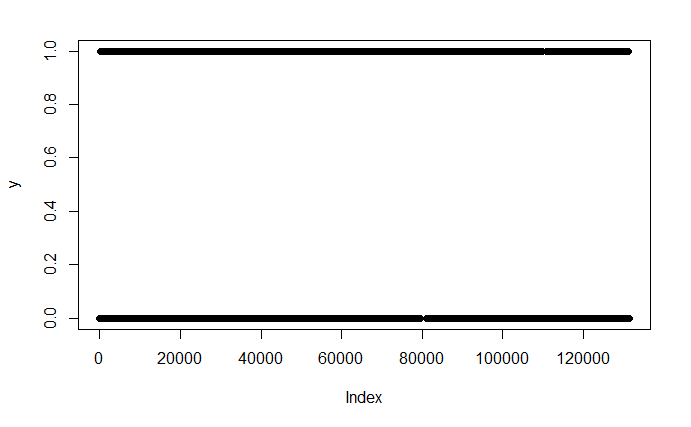

```r
y <- clipping(monSignal)
plot(y)
```

La fonction `clipping` binarise le signal en fonction de sa position relative à la moyenne.

Désanvantage : les extremums sont mélanger avec des non extremums.

Avantage : en répétant cette fonction de manière récursive, il possible d’atteindre n’importe quelle résolution.

# CoefComp

`lmCoef`,`rlmCoef`, `l1Coef` sont des fonctions qui déterminent les coéfficients d’un model linéaire. Ces fonctions ne nous interessent pas ici.

# Denorm_min_max

La fonction `denorme_min_max` dénormalise une série normalisée.

# Denorm_z

La fonction `denorm_z` dénormalise une série normalisée par une gaussienne.

# Elect_load

C’est un dataset de test qui ne nous interresse pas.

# Fast_stat

Les fonctions `maxC`,`minC`,`meanC`,`sumC`,`medianC` permettent de calculer une valeur caractéristique rapidement.

# MAAPE

La fonction `maape` calcule le MAAPE.

# MAE

La fonction `mae` calcule le MAE.

# MAPE

La fonction `mape` calcule le MAPE.

# MASE

La fonction `mase` calcule le MASE.

# MdAE

La fonction `mdae` calcule le MdAE.

# Min-Max normalises

Les fonctions `norm_min_max` et `norm_min_max_list` effectuent une normalisation Min-Max.

# Z-score

Les fonctions `norm_z` et `norm_z_list` effectuent une normalisation gausienne.

# DCT représentation

DCT : Discrete Cosine Transforme

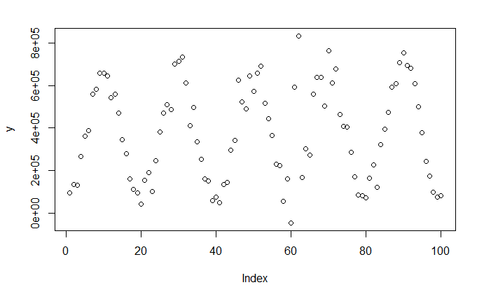

```r
n <- 100
y <- repr_dct(monSignal,coef=n)
plot(y)
```

# DFT représentation par FFT

DFT : Discrete Fourier Transform by Fast Fourier Transform

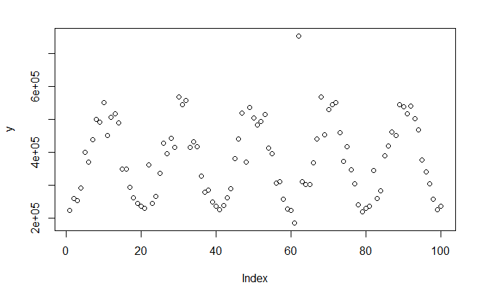

```r
n <- 100
y <- repr_dft(monSignal,coef=n)
plot(y)
```

# DWT représentation

DWT : Discrete Wavelet Transform

## filter haar

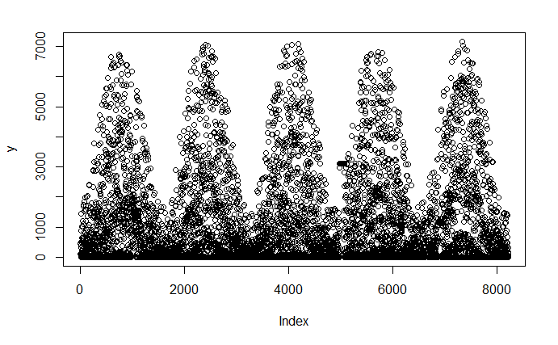

```r
level = 4
filter <- "haar"
y <- repr_dwt(monSignal,level=level,filter = filter)
plot(y)
```

## filter d4, d6, …, d20

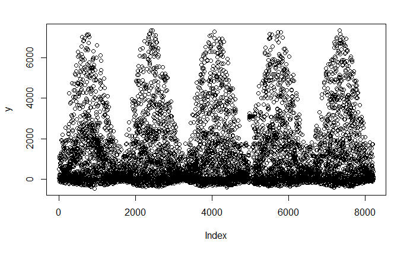

```r
level = 4
filter <- "d4"
y <- repr_dwt(monSignal,level=level,filter = filter)
plot(y)
```

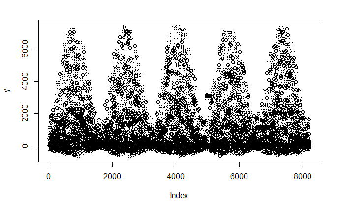

```r
level = 4
filter <- "d6"
y <- repr_dwt(monSignal,level=level,filter = filter)
plot(y)
```

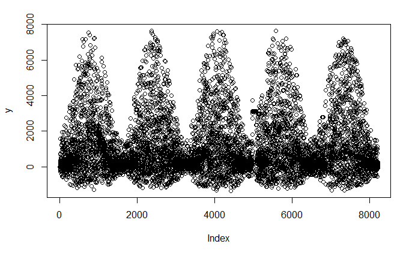

```r
level = 4
filter <- "d20"
y <- repr_dwt(monSignal,level=level,filter = filter)
plot(y)
```

## filter la8, la10, …, la20

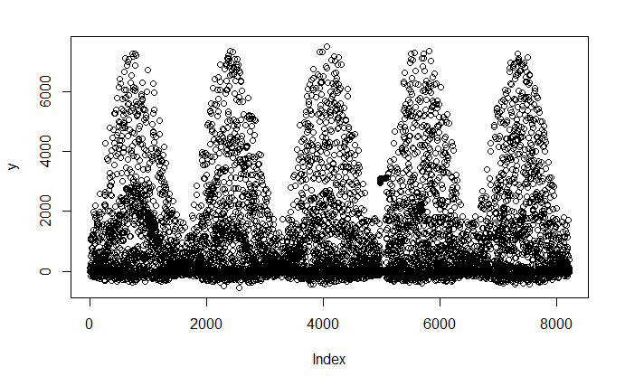

```r
level = 4
filter <- "la8"
y <- repr_dwt(monSignal,level=level,filter = filter)
plot(y)
```

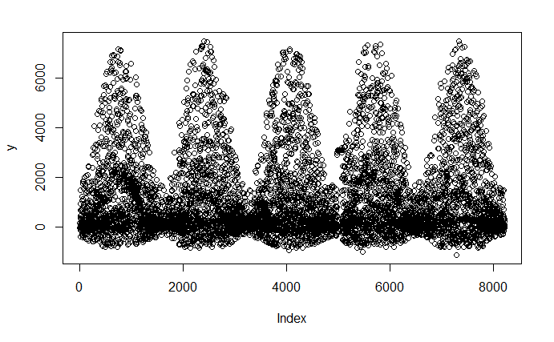

```r
level = 4
filter <- "la10"
y <- repr_dwt(monSignal,level=level,filter = filter)
plot(y)
```

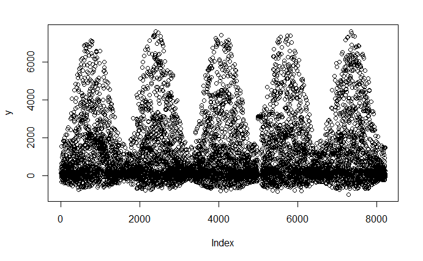

```r
level = 4
filter <- "la20"
y <- repr_dwt(monSignal,level=level,filter = filter)
plot(y)
```

## filter bl14, bl18, bl20

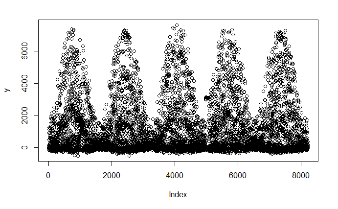

```r
level = 4
filter <- "bl14"
y <- repr_dwt(monSignal,level=level,filter = filter)
plot(y)
```

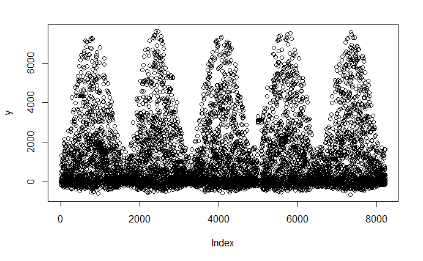

```r
level = 4
filter <- "bl18"
y <- repr_dwt(monSignal,level=level,filter = filter)
plot(y)
```

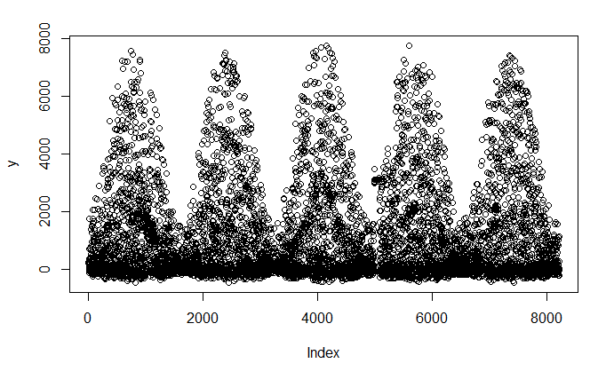

```r
level = 4
filter <- "bl20"
y <- repr_dwt(monSignal,level=level,filter = filter)
plot(y)
```

## filter c6, c12, …, c30

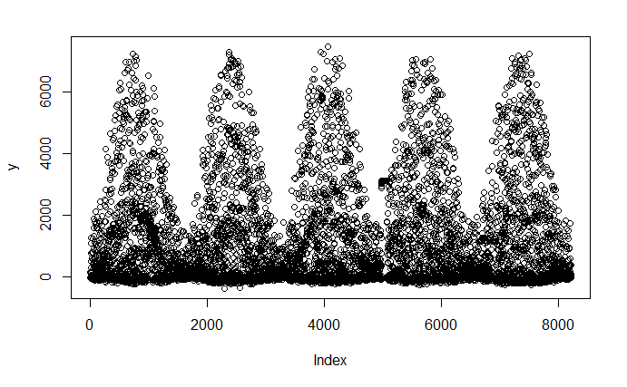

```r
level = 4
filter <- "c6"
y <- repr_dwt(monSignal,level=level,filter = filter)
plot(y)
```

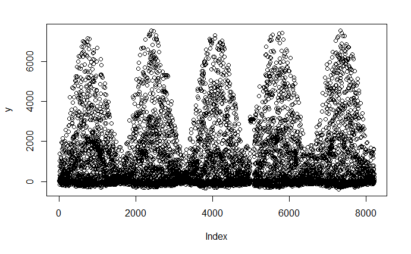

```r
level = 4
filter <- "c12"
y <- repr_dwt(monSignal,level=level,filter = filter)
plot(y)
```

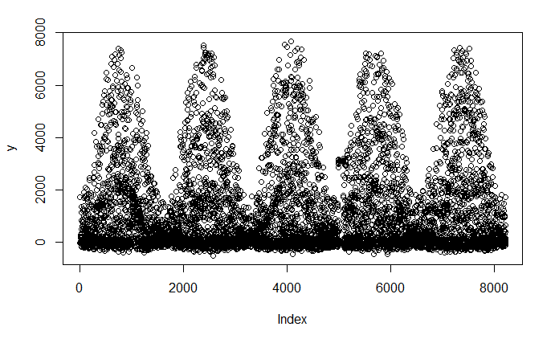

```r
level = 4
filter <- "c30"
y <- repr_dwt(monSignal,level=level,filter = filter)
plot(y)
```

# Exponential smoothing seasonal coefficients as representation

References : Laurinec P, Lucka M (2016) Comparison of representations of time series for clustering smart meter data. In: Lecture Notes in Engineering and Computer Science: Proceedings of The World Congress on Engineering and Computer Science 2016, pp 458-463 Laurinec P, Loderer M, Vrablecova P, Lucka M, Rozinajova V, Ezzeddine AB (2016) Adaptive time series forecasting of energy consumption using optimized cluster analysis. In: Data Mining Workshops (ICDMW), 2016 IEEE 16th International Conference on, IEEE, pp 398-405

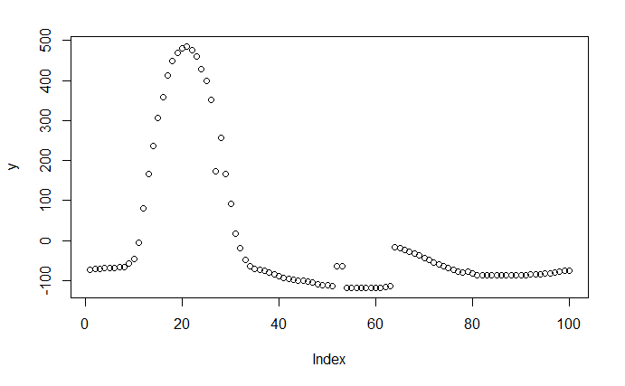

```r
freq <- 100
y <- repr_exp(monSignal,freq)
plot(y)
```

Prérequis : Au moins 2 répétitions du signal.

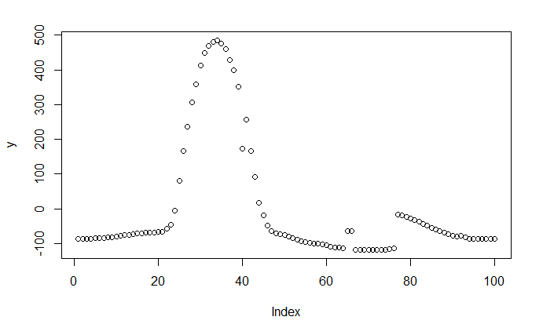

```r
freq <- 100
y <- repr_exp(c(monSignal,monSignal),freq)
plot(y)
```

# FeaClip representation

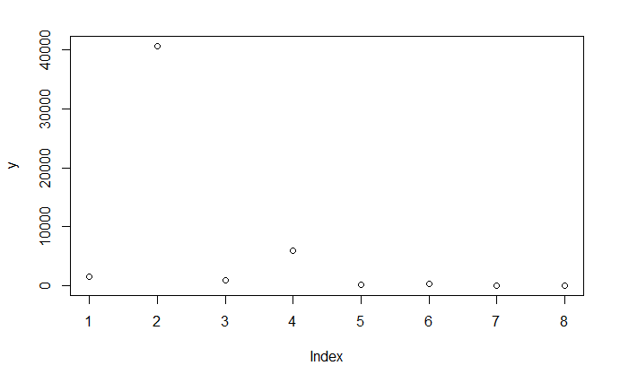

```r
y <- repr_feaclip(monSignal)
plot(y)
```

C’est une sorte de compresion RLE

# FeaClipTrend representation of time series

## sumC

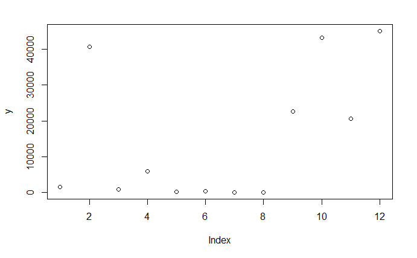

```r
func <- sumC
pieces <- 2L
order <- 4L
y<-repr_feacliptrend(x=monSignal, func=func,pieces=pieces,order=order)
plot(y)
```

## maxC

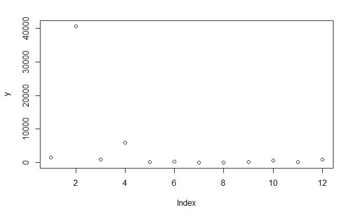

```r
func <- maxC
pieces <- 2L
order <- 4L
y<-repr_feacliptrend(x=monSignal, func=func,pieces=pieces,order=order)
plot(y)
```

# FeaTrend representation of time series

## sumC

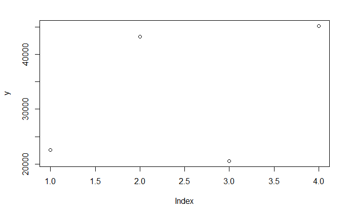

```r
func <- sumC
pieces <- 2L
order <- 4L
y<-repr_featrend(x=monSignal, func=func,pieces=pieces,order=order)
plot(y)
```

## maxC

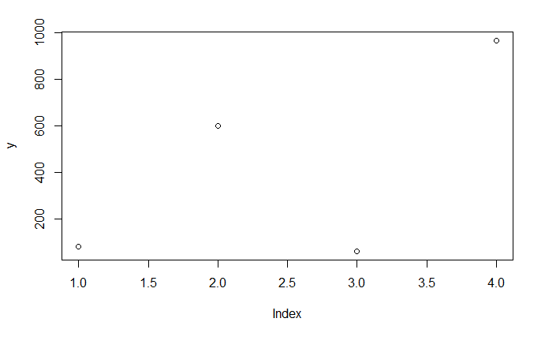

```r
func <- maxC
pieces <- 2L
order <- 4L
y<-repr_featrend(x=monSignal, func=func,pieces=pieces,order=order)
plot(y)
```

# GAM regression coefficients as representation

```r
y<-repr_gam(x=monSignal)
```

```
Error in as.formula(m_form) : object 'm_form' not found
```

Ne fonctionne pas !

# Regression coefficients from linear model as representation

## LM method

```r
method <- "lm"
freq <- 1000
y<- repr_lm(x=monSignal, method = method,freq=freq)
```

## L1 method

# Computation of matrix of representations from matrix of time series